# Useful Functions

```r
library(tidyverse)
library(psych)
library(palmerpenguins)
library(janitor)
library(gt)
library(papaja)
library(ggeasy)
library(patchwork)
library(ggbeeswarm)
```

- favorite function!
- more on tables
  - when creating tables, avoid typing numbers out
  - fmt_number() should be able to list multiple columns
- summarise_across
- learn how to write functions
- knit to pdf/word (maybe next week)

## case_when() example

```r
load(file = "brick/merged.rda")

mydata <- merged %>%
  filter(study == "Prolific") %>%
  select(id, age, female) %>%
  na.omit() %>%
  distinct(id, age, female)

range(mydata$age)
```

```
## [1] 18 76
```

```r
mydata %>%
  mutate(age_groups = case_when(age > 20 & age < 30 ~ "20s",
                                age >= 45 ~ "Older"))
```

```
## # A tibble: 799 x 4
##       id   age female age_groups
##    <dbl> <dbl> <chr>  <chr>
##  1  1001    21 1      20s
##  2  1002    21 1      20s
##  3  1003    37 2      <NA>
##  4  1004    35 2      <NA>
##  5  1005    24 1      20s
##  6  1006    26 3      20s
##  7  1007    47 2      Older
##  8  1008    51 2      Older
##  9  1009    48 2      Older
## 10  1010    54 1      Older
## # ... with 789 more rows
```

## sd and se

```r
library(palmerpenguins)
penguins <- penguins %>%
  na.omit()

# get mean, sd, n, se body mass for males and females
penguins %>%
  group_by(sex) %>%
  summarise(mean_bm = mean(body_mass_g),
            sd_bm = sd(body_mass_g),
            n_bm = n(),
            se = sd_bm/sqrt(n_bm))
```

```
## # A tibble: 2 x 5
##   sex    mean_bm sd_bm  n_bm    se
##   <fct>    <dbl> <dbl> <int> <dbl>
## 1 female   3862.  666.   165  51.9
## 2 male     4546.  788.   168  60.8
```

## summarise across & mutate across

```r
penguins %>%
  summarise(across(contains("mm"), list(mean_peng = mean, sd_peng = sd), na.rm=TRUE))
```

```
## # A tibble: 1 x 6
##   bill_length_mm_mean~ bill_length_mm_sd_~ bill_depth_mm_mea~ bill_depth_mm_sd_~
##                  <dbl>               <dbl>              <dbl>              <dbl>
## 1                 44.0                5.47               17.2               1.97
## # ... with 2 more variables: flipper_length_mm_mean_peng <dbl>,
## #   flipper_length_mm_sd_peng <dbl>
```

```r
penguins %>%
  mutate(across(species:island, as.character))
```

```
## # A tibble: 333 x 8
##    species island    bill_length_mm bill_depth_mm flipper_length_mm body_mass_g
##    <chr>   <chr>              <dbl>         <dbl>             <int>       <int>
##  1 Adelie  Torgersen           39.1          18.7               181        3750
##  2 Adelie  Torgersen           39.5          17.4               186        3800
##  3 Adelie  Torgersen           40.3          18                 195        3250
##  4 Adelie  Torgersen           36.7          19.3               193        3450
##  5 Adelie  Torgersen           39.3          20.6               190        3650
##  6 Adelie  Torgersen           38.9          17.8               181        3625
##  7 Adelie  Torgersen           39.2          19.6               195        4675
##  8 Adelie  Torgersen           41.1          17.6               182        3200
##  9 Adelie  Torgersen           38.6          21.2               191        3800
## 10 Adelie  Torgersen           34.6          21.1               198        4400
## # ... with 323 more rows, and 2 more variables: sex <fct>, year <int>
```

## gt

- https://gt.rstudio.com/articles/intro-creating-gt-tables.html
- https://rpubs.com/jsloane/QnA_week6

```r
# exibble (example tibble) is part of the gt package

# I'm adding a couple of extra columns to demonstrate what we can do with gt
my_table <- exibble %>%
  mutate(perc = c(10, 20, 30, 40, 50, 60, 70, 80),
         sd = c(.1, .1, .25, .2, .1, .1, .3, .25))

my_table %>%
  gt()
```

| num | char | fctr | date | time | datetime | currency | row | group | perc | sd |
| --- | --- | --- | --- | --- | --- | --- | --- | --- | --- | --- |
| 1.111e-01 | apricot | one | 2015-01-15 | 13:35 | 2018-01-01 02:22 | 49.950 | row_1 | grp_a | 10 | 0.10 |
| 2.222e+00 | banana | two | 2015-02-15 | 14:40 | 2018-02-02 14:33 | 17.950 | row_2 | grp_a | 20 | 0.10 |
| 3.333e+01 | coconut | three | 2015-03-15 | 15:45 | 2018-03-03 03:44 | 1.390 | row_3 | grp_a | 30 | 0.25 |
| 4.444e+02 | durian | four | 2015-04-15 | 16:50 | 2018-04-04 15:55 | 65100.000 | row_4 | grp_a | 40 | 0.20 |
| 5.550e+03 | NA | five | 2015-05-15 | 17:55 | 2018-05-05 04:00 | 1325.810 | row_5 | grp_b | 50 | 0.10 |
| NA | fig | six | 2015-06-15 | NA | 2018-06-06 16:11 | 13.255 | row_6 | grp_b | 60 | 0.10 |
| 7.770e+05 | grapefruit | seven | NA | 19:10 | 2018-07-07 05:22 | NA | row_7 | grp_b | 70 | 0.30 |
| 8.880e+06 | honeydew | eight | 2015-08-15 | 20:20 | NA | 0.440 | row_8 | grp_b | 80 | 0.25 |

```r
my_table %>%
  gt(
    rowname_col = "row",
    groupname_col = "group"
  ) %>%
  cols_hide( # hide columns
    columns = vars(date, time, fctr, char, datetime) # make sure to use vars()
  ) %>%
  fmt_number( # format numbers to 2 decimal places
    columns = vars(num, currency),
    decimals = 2
  ) %>%
  fmt_number( ### get parentheses!
    columns = vars(sd),
    pattern = "({x})"
  )  %>%
  fmt_percent( # format percent
    columns = vars(perc),
    scale_values = FALSE, # by default this is set to try which multiplies the variable by 100
    decimals = 0
  ) %>%
  cols_merge( # merge columns into 1
     columns = vars(perc, sd) #,
    # pattern = "{1} ({2})" # or this also works to add parentheses in columns you are merging
  ) %>%
  cols_label( # added this
    perc = "% (sd)",
  ) %>%
  fmt_currency( # add currency
    columns = vars(currency),
    currency = "AUD"
  ) %>%
  tab_header( # title and subtitle
    title = md("Example Table from **exibble**"), # md is to allow markdown formatting
    subtitle = md("`exibble` is an gt dataset")
  ) %>%
  tab_footnote( # you can add 1 or more footnotes
    footnote = "These are lower prices",
    locations = cells_body(
      columns = vars(currency),
      rows = currency < 15
    )
  ) %>%
  tab_footnote(
    footnote = "These big numbers",
    locations = cells_body(
      columns = vars(num),
      rows = num > 500
    )
  )
```

Example Table from **exibble**

`exibble` is an gt dataset

|  | num | currency | % (sd) |
| --- | --- | --- | --- |
| grp_a |  |  |  |
| row_1 | 0.11 | $49.95 | 10% (0.10) |
| row_2 | 2.22 | $17.95 | 20% (0.10) |
| row_3 | 33.33 | $1.39<sup>1</sup> | 30% (0.25) |
| row_4 | 444.40 | $65,100.00 | 40% (0.20) |
| grp_b |  |  |  |
| row_5 | 5,550.00<sup>2</sup> | $1,325.81 | 50% (0.10) |
| row_6 | NA | $13.26<sup>1</sup> | 60% (0.10) |
| row_7 | 777,000.00<sup>2</sup> | NA | 70% (0.30) |
| row_8 | 8,880,000.00<sup>2</sup> | $0.44<sup>1</sup> | 80% (0.25) |

<sup>*1*</sup> These are lower prices <sup>*2*</sup> These big numbers

## functions

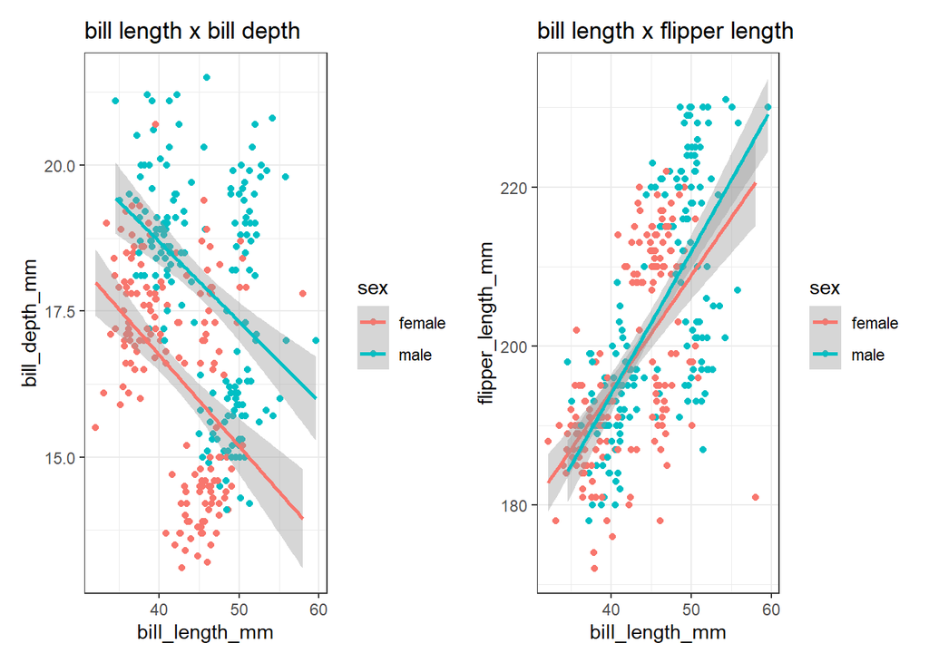

```r
# y axis = bill depth
penguins1 <- ggplot(penguins, aes(bill_length_mm, bill_depth_mm, color=sex)) +
  geom_point() +
  geom_smooth(method = "lm") +
  theme_bw() +
  labs(title = "bill length x bill depth")


# y axis = flipper length
penguins2 <- ggplot(penguins, aes(bill_length_mm, flipper_length_mm, color=sex)) +
  geom_point() +
  geom_smooth(method = "lm") +
  theme_bw() +
  labs(title = "bill length x flipper length")

penguins1 + penguins2
```

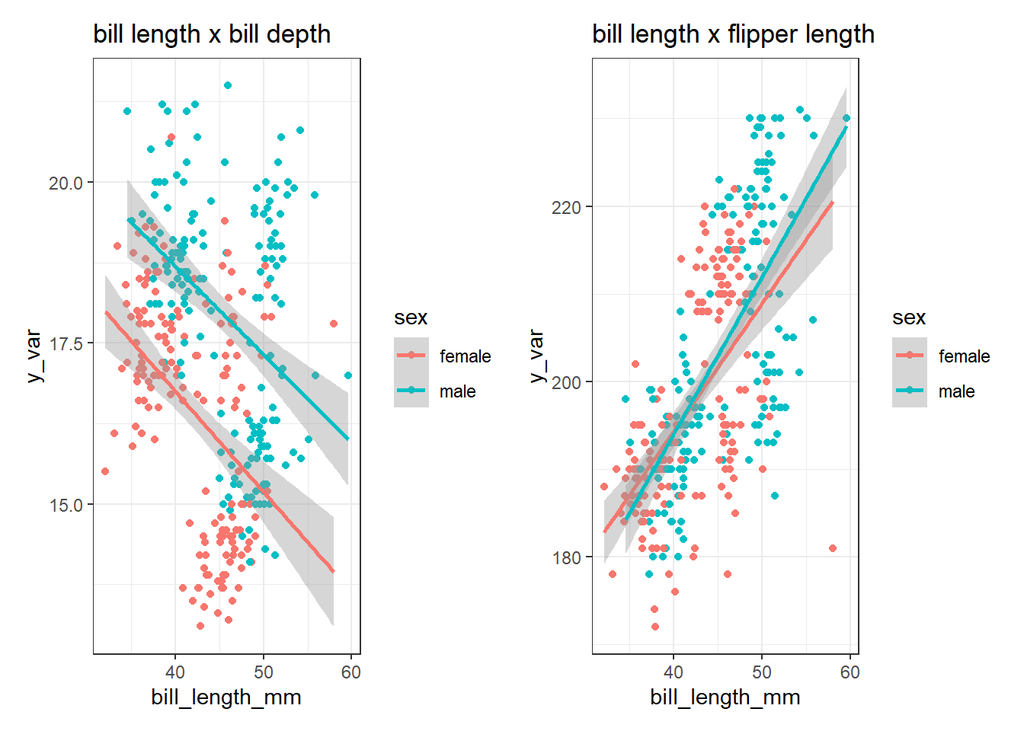

```r
## function

penguins_plot <- function(y_var, plot_title) {

  ggplot(penguins, aes(bill_length_mm, y_var, color=sex)) +
    geom_point() +
    geom_smooth(method = "lm") +
    theme_bw() +
    labs(title = plot_title)

}


plot1 = penguins_plot(y_var = penguins$bill_depth_mm, plot_title = "bill length x bill depth")

plot2 = penguins_plot(y_var = penguins$flipper_length_mm, plot_title = "bill length x flipper length")


plot1 + plot2
```

## Walter paper

- Figure 4, try to figure out which point is the outlier
- add text to see which point is which country (looks like your group already solved this!)
- What does the tilde sign mean, for example in the context of, case_when(sex == 0 ~ “female”) ?
- Last week, we used the line labs(x = expression(paste(“Mahalanobis”, italic(“D”))) to make the “D” in our figure show up in italics. We figured out that paste() converts something into a string and allows us to combine strings together. However, we are not quite sure what expression() is doing. The definition we got from the R Documentation is that expression() refers to “R objects, typically calls, symbols or constants.” Is it just a general function to put stuff in, kind of like c() which is used to create a vector?

## Harris paper

- error bars cut off after flipping the axis - potential data points out of the ylim?
- Given that the original graphs in the articles are flipped, would it be appropriate for us to also format the graphs so that it fully replicates the graph? Wouldn’t this count as malpractice?
- Why does the Hmsic package need to be installed in order for errorbars to appear when the errorbars function is part of the ggplot2 package?
- Are there any alternative functions to creating gradients in scatterplots?
- think about what would you have been able to do without the author’s code?

*Thenuka’s group - mean centered variables* I think Harris paper - Hannah’s learning log: We first mean centered the variables by subtracting the grand mean from the attitudes mean and created a new column with these values labelled meanA_c.

## Nichols paper

- slow/fast scale 1-5 reverse coded slow - 7
- slow 5 = fastest
- The Rmd file in OSF computes the tempo variable in the following manner: tempo = (fast + abs(slow-7))/2 So, they’ve taken an average on the fast variable and the reverse coding of the slow variable but we are not sure WHY the slow variable (originally measured on a scale of 1-5) has been reverse coded using -7 and not -6? It doesn’t make much sense to us because you end up with the slow variable being measure on a scale of 2-6, and not 1-5 like the fast variable?
- table: replace NA with -
- remove column label from first column
- change x axis value labels